# Network Analysis

Author

Lejla Beganovic

# Task 1: Centrality

In this task, the cycle network of Switzerland is analysed using R. The dataset comes from the **Federal Roads Office FEDRO** (ASTRA). The goal is to compute three different centrality measures (**degree**, **closeness**, and **betweenness**) for the nodes in the network and visualise the results.

## Step 1: Load libraries

```r
library(sf)
library(sfnetworks)
library(tidygraph)
library(dplyr)
library(ggplot2)
library(patchwork)
library(scales)
```

## Step 2: Load the data

Both layers are loaded as `sf` objects. The Veloland network is already in the Swiss national projection EPSG:2056 (CH1903+ / LV95), so no reprojection is needed. The `length` column already contains the edge length in metres.

```r
pfad <- "C:/Users/Lejlum/network_analysis"

veloland_lines <- st_read(file.path(pfad, "veloland.gpkg"), quiet = TRUE)
orte           <- st_read(file.path(pfad, "locations.gpkg"), quiet = TRUE)
```

## Step 3: Convert to an undirected network

The `sf` line layer is converted to an undirected `sfnetwork` object. An undirected network is appropriate here because cycling routes can be traversed in both directions.

```r
net <- as_sfnetwork(veloland_lines, directed = FALSE)
```

## Step 4: Compute centrality measures

The nodes are activated and three new columns are created using `dplyr::mutate()`. Edge length is used as the weight for closeness and betweenness, so that longer edges are treated as more costly to traverse.

```r
net_c <- net %>%
  activate(nodes) %>%
  mutate(
    degree      = centrality_degree(),
    closeness   = centrality_closeness(weights = length),
    betweenness = centrality_betweenness(weights = length)
  )
```

## Step 5: Convert back to sf objects

Both the enriched nodes and the edges are extracted as `sf` objects.

```r
veloland_nodes <- net_c %>% activate(nodes) %>% st_as_sf()
veloland_edges <- net_c %>% activate(edges) %>% st_as_sf()
```

## Step 6: Transfer centrality values to edges

The centrality values are attached to the nodes. `aggregate()` transfers them to the edges by computing the mean over all nodes for each edge.

```r
veloland_edges_c <- aggregate(veloland_nodes, veloland_edges, FUN = "mean")
```

## Step 7: Normalise values and visualise

The three measures have very different scales and distributions. To make them directly comparable, all values are normalised to the interval [0, 1] using `scales::rescale()`.

```r
veloland_edges_c <- veloland_edges_c %>%
  mutate(
    degree_norm      = scales::rescale(degree),
    closeness_norm   = scales::rescale(closeness),
    betweenness_norm = scales::rescale(betweenness)
  )
```

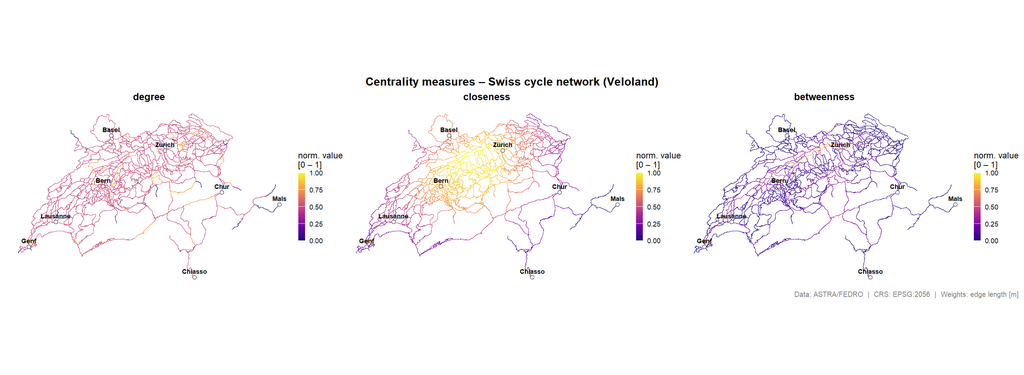

Figure 1: Centrality measures for the Swiss cycle network (Veloland). All values normalised to [0, 1]. Red/yellow = high, purple = low.

```r
make_map <- function(data, fill_var, title, orte) {
  ggplot() +
    geom_sf(data = data, aes(color = .data[[fill_var]]), linewidth = 0.3) +
    scale_color_viridis_c(
      option = "plasma",
      name   = "norm. value\n[0 – 1]",
      limits = c(0, 1),
      guide  = guide_colorbar(barwidth = 0.5, barheight = 5)
    ) +
    geom_sf(data = orte, shape = 21, fill = "white", color = "black",
            size = 1.8, stroke = 0.5) +
    geom_sf_text(data = orte, aes(label = Ortschaft),
                 size = 2.4, fontface = "bold", vjust = -0.8, color = "black") +
    labs(title = title) +
    theme_void(base_size = 9) +
    theme(
      plot.title      = element_text(size = 10, face = "bold",
                                     hjust = 0.5, margin = margin(b = 4)),
      legend.position = "right"
    )
}

p_degree      <- make_map(veloland_edges_c, "degree_norm",      "degree",      orte)
p_closeness   <- make_map(veloland_edges_c, "closeness_norm",   "closeness",   orte)
p_betweenness <- make_map(veloland_edges_c, "betweenness_norm", "betweenness", orte)

(p_degree | p_closeness | p_betweenness) +
  plot_annotation(
    title   = "Centrality measures – Swiss cycle network (Veloland)",
    caption = "Data: ASTRA/FEDRO  |  CRS: EPSG:2056  |  Weights: edge length [m]",
    theme   = theme(
      plot.title          = element_text(size = 12, face = "bold", hjust = 0.5),
      plot.title.position = "plot",
      plot.caption        = element_text(size = 7.5, color = "grey50", hjust = 1)
    )
  )
```

## Step 8: Discussion

**Closeness (centre):** The spatial gradient is most clearly visible here: the Mittelland is bright (high closeness) while the periphery remains dark. The Zürich/Bern/Basel region has the highest values. From there, all other nodes in the network can be reached via short total distances. Ticino, Geneva and Graubünden are peripheral and poorly connected, which reflects the Alpine topography: long detours through valleys strongly increase network distances.

**Conclusion:** The three measures capture different aspects of centrality. Degree reflects local connectivity, closeness indicates geographical position within the overall network, and betweenness identifies infrastructurally critical connections, which is particularly relevant for network planning and resilience analysis.

# Task 2: Routing

In this task, shortest paths are calculated between one selected origin location and all other destination locations in the dataset, using the same Veloland network as in Task 1.

## Step 1: Load libraries and data

```r
library(sf)
library(sfnetworks)
library(dplyr)
library(ggplot2)
```

```r
veloland_lines <- st_read(file.path(pfad, "veloland.gpkg"), quiet = TRUE)
orte           <- st_read(file.path(pfad, "locations.gpkg"), quiet = TRUE)

net <- as_sfnetwork(veloland_lines, directed = FALSE)
```

## Step 2: Define origin and destination

The first location (Chiasso) is selected as the origin. All other locations serve as destinations.

```r
orte$Ortschaft  # available cities
```

```
[1] "Chiasso"  "Genf"     "Lausanne" "Bern"     "Basel"    "Zürich"   "Chur"
[8] "Mals"
```

```r
origin      <- orte[1, ]   # Chiasso
destination <- orte[-1, ]  # all other 7 cities
```

## Step 3: Calculate shortest paths

`st_network_paths()` computes the shortest path from the origin to each destination, weighted by edge length.

```r
paths <- st_network_paths(
  net,
  from    = origin,
  to      = destination,
  weights = "length"
)

paths
```

```
# A tibble: 7 × 2
  node_paths edge_paths
  <list>     <list>
1 <int [68]> <int [67]>
2 <int [77]> <int [76]>
3 <int [56]> <int [55]>
4 <int [86]> <int [85]>
5 <int [56]> <int [55]>
6 <int [25]> <int [24]>
7 <int [30]> <int [29]>
```

The result is a tibble with two list columns: `node_paths` (node indices) and `edge_paths` (edge indices). The `edge_paths` column is used in the next step to reconstruct the geometry of each path.

## Step 4: Create sf objects for each path

The edges of the network are extracted as an `sf` object. For each path, the corresponding edges are filtered using the indices from `edge_paths` and combined with a destination label.

```r
net_edges <- net %>% activate(edges) %>% st_as_sf()

path_lines <- lapply(seq_len(nrow(paths)), function(i) {
  edge_ids <- paths$edge_paths[[i]]
  segment  <- net_edges[edge_ids, ]
  segment$destination <- destination$Ortschaft[i]
  segment
})

all_paths <- do.call(rbind, path_lines)
```

## Step 5: Visualise

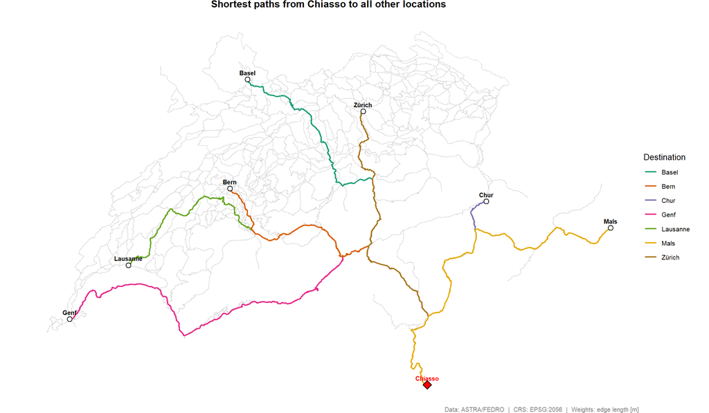

Figure 2: Shortest paths from Chiasso (red diamond) to all other locations. Each path is shown in a distinct colour. The grey background shows the full Veloland network.

```r
ggplot() +
  geom_sf(data = net_edges,
          color = "grey80", linewidth = 0.2) +
  geom_sf(data = all_paths,
          aes(color = destination), linewidth = 0.8) +
  geom_sf(data = destination,
          shape = 21, fill = "white", color = "black",
          size = 2.5, stroke = 0.7) +
  geom_sf(data = origin,
          shape = 23, fill = "red", color = "black",
          size = 3.5, stroke = 0.7) +
  geom_sf_text(data = destination,
               aes(label = Ortschaft),
               size = 2.6, fontface = "bold",
               vjust = -0.9, color = "black") +
  geom_sf_text(data = origin,
               aes(label = Ortschaft),
               size = 2.6, fontface = "bold",
               vjust = -0.9, color = "red") +
  scale_color_brewer(palette = "Dark2", name = "Destination") +
  labs(
    title   = paste0("Shortest paths from ", origin$Ortschaft,
                     " to all other locations"),
    caption = "Data: ASTRA/FEDRO  |  CRS: EPSG:2056  |  Weights: edge length [m]"
  ) +
  theme_void(base_size = 10) +
  theme(
    plot.title   = element_text(size = 12, face = "bold",
                                hjust = 0.5, margin = margin(b = 6)),
    plot.caption = element_text(size = 7.5, color = "grey50", hjust = 1),
    legend.position = "right"
  )
```

## Discussion

These results illustrate how Alpine topography strongly constrains routing in the Swiss cycle network: detours through valleys make distances much longer than straight-line distances would suggest, and a small number of mountain crossings act as unavoidable chokepoints for nearly all long-distance routes.

# Declaration of AI Use

In accordance with the ZHAW Z-RL-Guidelines on AI in assessments (01.04.2023), I declare that I used Claude (Anthropic) as an AI assistant during this assignment.

Claude supported me with debugging errors, correcting text phrasing, and explaining `sfnetworks` and `tidygraph` concepts.

All decisions about structure, approach, and content were made by me. I understood each correction before applying it, and Claude served as a troubleshooting and learning aid rather than a replacement for my own work.